# Team.Rmd

Ethan Wanlass & Hailey Braun

9/18/2019

## GitHub Repository Html

https://github.com/ewanlass/ds202_lab2

## Coding Comments

```r
recent_rating = choco[choco$Review.Date>2011,]
#It creates a new data frame that includes all the review rating after 2011

unique(recent_rating$Company.Location) # NOTICE: how many countries are listed but how many levels are there?
#It reveals the different location of different companties in the "recent_ratings" data frame.

recent_rating$Company.Location = droplevels(recent_rating$Company.Location)
#It taking away the levels (countries that don't have applicable data point) from the data frame. Both levels and cournties are the same

head(recent_rating)
# gives the first 6 values of the data frame "recent_rating"

cross_table = table(recent_rating$Review.Date,recent_rating$Company.Location)
cross_table
# creating a table thats gives the count of company locations per year in the recent_rating data set. And reveals a table.

which(cross_table[1,]!=0 & cross_table[2,]!=0 & cross_table[3,]!=0 & cross_table[4,]!=0 & cross_table[5,]!=0)
#in the cross_table it takes all of the countries that have does not have 0 every year from 2012 - 2017.

france_recent = subset(recent_rating,Company.Location =='France')
uk_recent = subset(recent_rating,Company.Location =='U.K.')
germany_recent = subset(recent_rating,Company.Location=='Germany')
#from the data frame recent_ratings creating a subset and calling it "countryname"_recent which finds the recent ratings for the company specific to the country.

par(mfrow=c(2,2))
color1 = ifelse(france_recent$Rating >median(france_recent$Rating), 'blue', 'green')
plot(france_recent$Cocoa.Pct ~ france_recent$Review.Date,ylim=c(50,90),col=color1,pch=18,cex=1.5,xlab="Review Date", ylab= "Cocoa Percentage", main= "France")
legend('bottomright',legend=c('High Rating', 'Low Rating'),col=c('blue','green'),pch=18)
#par(mfrow=c(2,2)) is setting parameters to the size of the plot that is given and in this case it is 2 units by 2 units. color1 is saying that any number that is over the median is to be labeled in blue and any value below the median is green. plot(france_recent$Cocoa.Pct = is the x value for the plot which is the cocoa percentage from the dataframe for France. france_recent$Review.Date = y value giving the review dates for France. ylim=c(50,90) = setting the y value range ,col=color1 is doing the colors according to how we specified color1 earlier,pch=18 is the character being used in the plot,cex=1.5 is the size of the symbols,xlab="Review Date" is the x label, ylab= "Cocoa Percentage" is the y label, main= "France" is the title of the plot)  legend('bottomright',legend=c('High Rating', 'Low Rating'),col=c('blue','green'),pch=18) creates the legend saying that you want it in the bottom right of the plot explaining the value to the colors that were given for color1.
color2 = ifelse(uk_recent$Rating >median(uk_recent$Rating), 'purple', 'red')
plot(uk_recent$Cocoa.Pct ~ uk_recent$Review.Date,ylim=c(50,90),col=color2,pch=18,cex=1.5, xlab="Review Date", ylab= "Cocoa Percentage", main= "UK")
legend('bottomright',legend=c('High Rating', 'Low Rating'),col=c('purple','red'),pch=18)

color3 = ifelse(germany_recent$Rating > median(germany_recent$Rating), 'orange', 'yellow')
plot(germany_recent$Cocoa.Pct ~ germany_recent$Review.Date,ylim=c(50,90),col=color3,pch=18,cex=1.5,xlab="Review Date", ylab= "Cocoa Percentage", main= "Germany")
legend('bottomright',legend=c('High Rating', 'Low Rating'),col=c('orange','yellow'),pch=18)
#these two were similar using different colors and countries
```

[output not shown]

## Additional Questions

2 . Click Zoom on the Rstudio window (under Plots) to see the plot more clearly. How do you think the plot produced from the code above can be improved? Recommend at least one possible improvement.

The legend box could be a bit smaller.

3 . How does the **number** of ratings (not the actual value of the rating) depend on the year? Use graphics to answer this question.

4 . How do ratings compare across different company locations? Focus on the three locations with the most ratings. Hint: the function `sort()` might come in handy here.

The three locations with the most ratings was USA, Canada and France. All of them averaged around 3.25, but USA had a slighly larger spread than both France and Canada. There wasn’t any extreme ratings. None of the ratings were below 1 or above 4.

Code used to answer it:

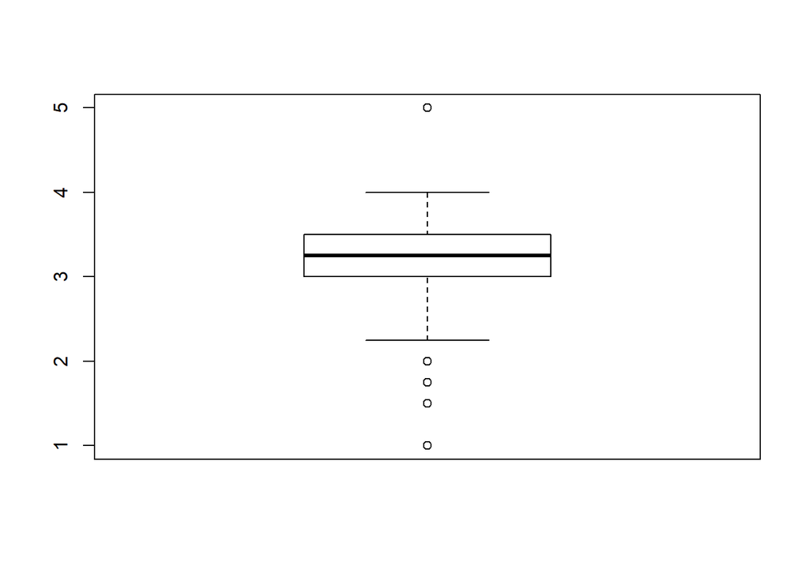

```r
choco <- read.csv("https://raw.githubusercontent.com/lbchu/ds202_labs/master/choco.csv")
boxplot(choco$Rating)
```

```r
sort(summary(choco$Company.Location),decreasing=TRUE)
```

```
##            U.S.A.            France            Canada              U.K.
##               787               158               132                98
##             Italy           Ecuador         Australia           Belgium
##                69                55                50                40
##       Switzerland           Germany           Austria             Spain
##                38                36                27                26
##          Colombia           Hungary         Venezuela            Brazil
##                23                23                20                18
##             Japan        Madagascar       New Zealand              Peru
##                17                17                17                17
##           Denmark           Vietnam         Guatemala          Scotland
##                16                11                10                10
##         Argentina        Costa Rica            Israel            Poland
##                 9                 9                 9                 8
##         Amsterdam          Honduras         Lithuania Domincan Republic
##                 6                 6                 6                 5
##         Nicaragua       South Korea            Sweden              Fiji
##                 5                 5                 5                 4
##           Ireland            Mexico       Netherlands       Puerto Rico
##                 4                 4                 4                 4
##          Sao Tome            U.A.E.           Grenada           Iceland
##                 4                 4                 3                 3
##          Portugal            Russia         Singapore      South Africa
##                 3                 3                 3                 3
##           Bolivia             Chile           Finland             India
##                 2                 2                 2                 2
##         St. Lucia    Czech Republic           Eucador             Ghana
##                 2                 1                 1                 1
##        Martinique         Niacragua       Philippines          Suriname
##                 1                 1                 1                 1
##             Wales
##                 1
```

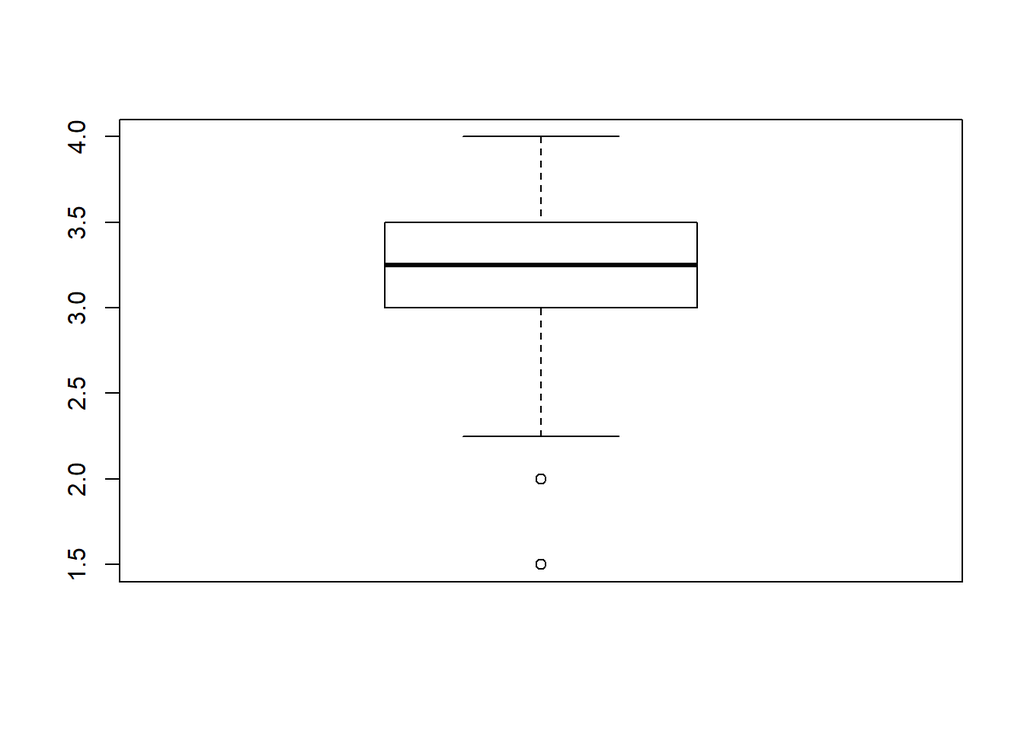

```r
variable = subset(choco, Company.Location=='Canada' | Company.Location == 'U.S.A.' | Company.Location == 'France')
boxplot(variable$Rating)
```

```r
sort(variable$Rating,decreasing = TRUE)
```

[output not shown]

[output cut: 68 more lines]

```r
Canada = subset(choco, Company.Location=='Canada')
USA = subset(choco, Company.Location=='U.S.A.')
France = subset(choco, Company.Location=='France')

par(mfrow=c(2,2))
boxplot(Canada$Rating)
boxplot(USA$Rating)
boxplot(France$Rating)

mean.default(Canada$Rating)
```

```
## [1] 3.3125
```

```r
mean.default(USA$Rating)
```

```
## [1] 3.162325
```

```r
mean.default(France$Rating)
```

```
## [1] 3.253165
```

[figure not shown]

5 . Brainstorm and write down an interesting question that can be answer from the dataset. The question should not duplicate the questions above.

What is an estimate of the highest rated cocoa percentage accross all countries?